# Hops Yields in PNW

Part I: Problem Statement and Data Analysis

Don A. Lloyd

6/24/2023

```r
require(data.table) # fwrite
require(tigris) # fips_codes
```

Problem Statement and Preliminaries

Hops yield data and hop growing counties

Climatic observations

Air quality observations

### Problem statement and preliminaries

Hops are essential to IPAs. Most hops grown in the US are grown in the Pacific North West (PNW) region, the states of Idaho, Oregon, and Washington. Climate change, including an increase in smoke and pollutants from fires, have negatively impacts crop yields and quality.

1. Do we see evidence that hop yields are sensitive to one or more climate or air quality factors?
2. Can we find useful causal inferential models?
3. Can we identify hop varieties that are more climate resilient, as measured by higher yields?

### Limitations and assumptions

Yields are reported by state but not by county. Yields are presumably affected by local measures of climatic and air quality variables. For this reason, we identify counties within the PNW states for selecting meteorological and air quality samplers from their respective data sets.

Hop harvests are reported on their annual growing cycle. Environmental impacts to the annual yield are distributed throughout the year. Even atmospheric chemistry outside of the hop growing months can affect soil nutrition. We cannot account for these factors without more sophisticated data and models. For this analysis, we assume annual yields are a consequence of impacts accumulated throughout the year.

Differences in field management and harvest techniques used by growers likely contribute to variations in yields that cannot be accounted for in this analysis.

### Hops yield data and their validation

```r
require(dplyr)
require(stringr)
require(tidyr)
require(tibble)
require(pdftools)
require(ggplot2)
require(data.table) # fwrite

require(usdarnass) # for validation against NASS data

# for background and explanatory info:
# https://en.wikipedia.org/wiki/List_of_hop_varieties
#
# for naming conventions see hopslist.com

pdf.path <- paste0(path.data, "/HGA/")
pdf.list <- dir(pdf.path, pattern = ".pdf", ignore.case = TRUE, full.names = TRUE)

# fn.yield <- "Hops.Rdata"
# if (file.exists(fn.yield)) {
#   yield0 <- readRDS(fn.yield)
#   pdf.list0 <- na.omit(unique(yield0$File))
#   i <- which(is.na(match(basename(pdf.list), pdf.list0)))
#   if (length(i) >0) pdf.list <- pdf.list[i] else
#     pdf.list <- NA
# }
```

```r
# read each report, find the yield table and extract it
listtbl <- lapply(pdf.list, function(x) {
  print(x)
  rawtext <- pdf_text(x) %>% str_split("\n")
  singlepage <- lapply(rawtext, function(x) Reduce(c, x))
  # find header lines
  hp <- grep("[[:digit:]]{4} Statistical .*", singlepage)
  hl <- grep("[[:digit:]]{4} Statistical .*", singlepage[[min(hp)]])
  # extract the reporting year
  year <- as.numeric(gsub(".*[ ]+([[:digit:]]{4}) Statistical .*", "\\1",
                          grep("[[:digit:]]{4} Statistical .*", singlepage[[min(hp)]], value = TRUE)
  ))
  out <- NULL
  # recent reports refer to "PNW HOP YIELDS", older reports use "U.S. HOP YIELDS"...
  ii <- grep("HOP YIELDS BY STATE", singlepage, ignore.case = TRUE)
  # find page in report that includes the current yield table by variety
  toc <- grep("HOP YIELDS.*VARIETY", unlist(singlepage[ii[1]]), ignore.case = TRUE, value = TRUE)
  pptxt <- gsub(".* ([0-9\\-]+)$", "\\1", toc)
  if (grepl("\\-", pptxt)) pptxt <- unlist(strsplit(pptxt, "\\-"))
  # can test if pp is defined
  pp <- as.numeric(pptxt)
  # isolate page numbers
  pagenumtarget = "[[:space:]]{5,}([[:digit:]ivx]+).*"
  pagenum <- sapply(1:length(singlepage), function(x) {
    pagerows <- grep(pagenumtarget, singlepage[[x]])
    if (length(pagerows) >0) {
      thispage <- max(pagerows)
      gsub(pagenumtarget, "\\1", singlepage[[x]][thispage])
    }
  })
  pp <- as.numeric(match(pptxt, pagenum))
  o <- trimws(unlist(singlepage[pp]))
  # A few files will add breaks before and or after TM labels in Variety names
  # sometimes leaving a row of numbers with no leading Variety name. We look
  # for the missing data in lines immediately preceding or following each row
  # missing a hop variety.
  # let's first eliminate "Hop Grower" lines
  o <- grep("^Hop Growers", o, invert = TRUE, value = TRUE)
  # then drop rows that are at least 5 char all caps (typically state names and some headings)
  o <- grep("^[[:upper:]]{5,}$", o, invert = TRUE, value = TRUE)
  # look for rows that start with a numeric (e.g. yield) entry that are otherwise complete -- these rows are missing a variety entry
  # this is a little cumbersome, but better than other methods I have tried...
  ifloat <- which(grepl("^[0-9,]{3,}|^TM[ ]+|^[12]{1}[ ]*", o) & nchar(o) >30)
  if (length(ifloat) >0) {
    cat("these rows appear to be missing variety labels\n")
    print(ifloat)
    # check previous 2 rows for varietal label that got left behind
    for (i in ifloat) {
      cat(sprintf("checking line %d:\n%s\n", i, o[i]))
      ivar <- c(i-2, i-1)
      # lets make it weird, in rare cases label gets shifted down one row
      # this logic is a little pedantic, but easier to read
      if (match(i, ifloat) < length(ifloat)) {
        ok <- (i+1 < ifloat[match(i, ifloat) +1] -2)
      } else {
        ok <- (i+1 < length(o))
      }
      if (ok) ivar <- c(ivar, i+1)
      print(o[sort(c(ivar,i))])
      ii <- which(nchar(o[ivar]) <16)
      if (length(ii) >0) {
        # replace corrected line using wide space so it parses with remainder of table
        # the partial lines we built labels from won't be parsed below...
        cat(sprintf("proposed label: %s\n", paste(o[ivar[ii]], collapse = " ")))
        o[i] <- paste(paste(o[ivar[ii]], collapse = " "), o[i], sep = "          ")
        print(o[i])
      } else {cat("no label text found...\n")}
    } # next line to build label for
  }
  # find rows that conform to a table definition
  rawtbl <- grep("([0-9,\\.]+|[\\*]){3,}", o, value = TRUE) %>%
    # replace blank space with a delimiter unique to the table
    gsub("[[:space:]]{2,}", "|", .) %>%
    gsub(",|%", "", .) %>% # drop comma and percentage formatting
    # next line partially fixes issues with extra spaces or footnote labels in first col
    gsub("([[:alpha:] \\!]+)\\|([[:alpha:] ]+|[123]?\\|.*)", "\\1 \\2", .)
  tblrows <- grep("\\|", rawtbl) # keep only lines we can parse
  rawtbl <- rawtbl[tblrows]
  # find header row
  h <- grep("Variety", rawtbl, ignore.case = TRUE)
  # header may be duplicated if table continues on second page
  # find start of next table
  h1 <- min(h)
  # n.b. this header appears to be consistent across the reports
  hdr <- unlist(strsplit(rawtbl[h1], split = "\\|"))
  # if there are three or more header rows with a split table, assume
  # they mark new tables that can be dropped...
  hh <- ifelse(length(h) >2, h[3] - 1, length(rawtbl))
  rawtbl <- rawtbl[1:hh] # dropping extra rows
  # eliminate stray headers
  rawtbl <- grep("& Variety", rawtbl, ignore.case = TRUE, value = TRUE, invert = TRUE)
  # ready to parse what is left
  parsedtbl <- read.table(text = rawtbl, skip = h1, sep = "|", fill = TRUE,
                          na.strings = c("*"), row.names = NULL,
                          col.names = hdr) %>%
    as_tibble %>%
    select(1, all_of(paste0("X", year))) %>%
    rename(Variety = 1, Yield = 2) %>%
    mutate(Yield = ifelse(grepl("[^[:digit:]]", Yield), NA, Yield)
           ,Yield = as.numeric(Yield)
           ,Year = year
           ,isTotal = grepl("Total", Variety)
           ,Variety = gsub("Total Idaho[ ]*1", "Total Idaho", Variety)
           ,State = ifelse(isTotal, trimws(gsub("Total", "", Variety)), NA)
           ,File = basename(x)
    ) %>%
    fill(State, .direction = "up")
  list(file = basename(x), tbl = parsedtbl, year = year,
       raw = rawtbl, o = o)
}) # next file
```

```
## [1] "/Users/dlloyd/Dropbox/Data/HGA//10.pdf"
## [1] "/Users/dlloyd/Dropbox/Data/HGA//105.pdf"
## these rows appear to be missing variety labels
## [1] 109
## checking line 109:
## TM                             330,500           324,900          435,700           356,200           417,100
## [1] "Amarillo®, VGXP01                           *                 *                *                 *        1,542,300"
## [2] "ApolloTM                             649,000           571,100          589,600           444,900           409,900        -7.87%"
## [3] "TM                             330,500           324,900          435,700           356,200           417,100"
## [4] "Bravo                                                                                                                      17.10%"
## no label text found...
## [1] "/Users/dlloyd/Dropbox/Data/HGA//11.pdf"
## [1] "/Users/dlloyd/Dropbox/Data/HGA//12.pdf"
## [1] "/Users/dlloyd/Dropbox/Data/HGA//13.pdf"
## [1] "/Users/dlloyd/Dropbox/Data/HGA//14.pdf"
```

[output cut: 169 more lines]

```r
years <- unlist(lapply(listtbl, function(x) x$year))
listtbl <- setNames(listtbl, years)
```

Abbreviations for some of the major hop breeders HBC = Hop Breeding Company VGX = Virgil Gamache Farms YCR = Yakima Chief Ranches ADHA = Association for the Development of Hop Agronomy (www.adha.us)

```r
# process each table, clean and parse variety names
hga_yield <-
  lapply(listtbl, function(x) x$tbl) %>%
  bind_rows() %>%
  filter(!str_detect(Variety, "TATE")) %>%
  # the 2012 report does not include the total rows for WA (or US/PNW)
  mutate(State = ifelse(is.na(State) & Year == 2012, "Washington", State)
         ,isTM = grepl("TM|T M|\\x99", Variety) # trademark
         ,isR = grepl(" R|R |\\xAE", Variety) # registered trademark
         # eliminate commas, parentheses and symbols from variety names
         ,Variety = gsub(",|\\(|\\)|TM|T M|\\x99|\\xAE|\\*", "", Variety)
         ,Variety = trimws(Variety) # clean up trailing spaces after symbol pass
         # ,Variety = gsub(",|\\(|\\)|TM|T M| R|R |\\x99|\\xAE", "", Variety)
         # contract multiple spaces
         ,Variety = gsub("[[:space:]]{2,}", " ", Variety)
         # eliminate strays spaces within variety names
         ,Variety = gsub("([[:alpha:]]+)[[:space:]]+([[:lower:]]+.*)", "\\1\\2", Variety)
         # drop subscripts from total and aggregate lines
         ,Variety = gsub("(Total|Other [A-Za-z]+)[ ]*[12]$", "\\1", Variety)
         # standardize variety names
         ,Variety = case_when(
           grepl("YCR[ ]*4|Palisade", Variety) ~ "Palisade YCR 4"
           ,grepl("YCR[ ]*5|Warrior", Variety) ~ "Warrior YCR 5"
           ,grepl("Super[ ]*Galena", Variety) ~ "Super Galena"
           ,grepl("Talus|692", Variety) ~ "Talus HBC 692"
           ,grepl("Summit", Variety) ~ "Summit"
           ,grepl("Ahtanum|YCR 1[^[:digit:]]*", Variety) ~ "Ahtanum YCR 1"
           ,grepl("ADHA-483|Azacca", Variety) ~ "Azacca ADHA-483"
           ,grepl("ADHA-881|Jarrylo", Variety) ~ "Jarrylo ADHA-881"
           ,grepl("Pekko|ADHA-871", Variety) ~ "Pekko ADHA-871"
           ,grepl("Citra|HBC 394", Variety) ~ "Citra HBC 394"
           ,grepl("Tettnang", Variety) ~ "Tettnanger"
           ,grepl("Loral|HBC 291", Variety) ~ "Loral HBC 291"
           ,grepl("Simcoe|YCR 14", Variety) ~ "Simcoe YCR 14"
           #,grepl("YCR 1", Variety) ~ "Ahtanum YCR 1"
           ,grepl("Hallertauer", Variety) ~ "Hallertau"
           ,grepl("Calyp so", Variety) ~ "Calypso" # unusual space...
           ,TRUE ~ Variety
         )
  )
# hga_yield table retains "Other" varieties and totals
hga_yield %>%
  pull(Variety) %>%
  sort %>%
  unique
```

```
##  [1] "Ahtanum YCR 1"           "Alpha"
##  [3] "Amarillo VGXP01"         "Apollo"
##  [5] "Aroma"                   "Azacca ADHA-483"
##  [7] "Bravo"                   "Calypso"
##  [9] "Cascade"                 "Cashmere"
## [11] "Centennial"              "Chelan"
## [13] "Chinook"                 "Citra HBC 394"
## [15] "Cluster"                 "Columbus/Tomahawk"
## [17] "Columbus/Tomahawk/Zeus"  "Comet"
## [19] "Crystal"                 "Ekuanot HBC 366"
## [21] "El Dorado"               "Eroica"
## [23] "Eureka!"                 "Experimental"
## [25] "Fuggle"                  "Galena"
## [27] "Glacier"                 "Golding"
## [29] "Hallertau"               "Hallertau Magnum"
```

[output cut: 23 more lines]

```r
# range of dates for this analysis are constrained by yield data
begin_date <- as.Date(sprintf("%d-01-01", min(hga_yield$Year)))
end_date <- as.Date(sprintf("%d-12-31", max(hga_yield$Year)))
```

```r
#############################
##
##  VALIDATE THE HGA DATA
##
#############################

cat(sprintf("pulling NASS data from %d to present\n", min(years)))
```

```
## pulling NASS data from 2000 to present
```

```r
# pull hops yields from the National Agriculture Statistics Server (NASS)
# avoids pulling a lot of older, more highly aggregated data that we won't use
# by setting year to first in HGA data set
hops_nass <- nass_data(
  source_desc = "SURVEY"
  ,sector_desc = "CROPS"
  ,commodity_desc = "HOPS"
  ,year = sprintf(">=%s", min(years))
  ,reference_period_desc = "YEAR"
)

hga_varieties <- hga_yield %>%
  pull(Variety) %>%
  sort %>%
  unique %>%
  toupper

# class_desc is variety
nass_simple <-
  hops_nass %>%
  tibble %>%
  mutate(Year = as.numeric(year)) %>%
  filter(statisticcat_desc == "YIELD"
         ,class_desc != "ALL CLASSES"
         ,agg_level_desc == "STATE"
         ,year >= 2000) %>%
  select(class_desc, Value, Year, state_name) %>%
  mutate(Yield = ifelse(grepl("\\(D\\)", Value), NA, gsub(",", "", Value))
         ,Yield = as.numeric(Yield)
         ,Variety = gsub(",| TM| R[^[:upper:]]| R$", "", class_desc)
         ,Variety = case_when(
           Variety == "MILLENIUM" ~ "MILLENNIUM" # fix NASS typo
           ,grepl("MITTEL", Variety) ~ "HALLERTAU"
           ,grepl("C/T/Z", Variety) ~ "COLUMBUS/TOMAHAWK" # HGA still use C/T label
           ,TRUE ~ Variety
         )
         ,State = str_to_title(state_name)
         ,Match = match(Variety, hga_varieties)
  ) %>%
  select(Variety, Yield, Year, State, Match)

# these are varieties tracked by NASS but not matched with
# HGA varieties. some may fall into the HGA "other" or "experimental"
# categories
nass_simple %>%
  filter(is.na(Match)) %>%
  pull(Variety) %>%
  unique
```

```
## [1] "BITTER GOLD" "BULLION"     "DELTA"       "IDAHO GEM"   "LEMONDROP"
## [6] "LOTUS"       "MERIDIAN"    "SULTANA"
```

```r
# new varieties are not yet established across multiple growers and
# yields are reported NA
nass_simple %>%
  filter(is.na(Match))
```

| Variety | Yield | Year | State | Match |
| --- | --- | --- | --- | --- |
| BITTER GOLD | NA | 2022 | Washington | NA |
| BITTER GOLD | NA | 2021 | Washington | NA |
| BITTER GOLD | NA | 2020 | Washington | NA |
| BITTER GOLD | NA | 2019 | Washington | NA |
| BULLION | NA | 2019 | Oregon | NA |
| DELTA | NA | 2021 | Oregon | NA |
| DELTA | NA | 2020 | Oregon | NA |
| DELTA | NA | 2019 | Oregon | NA |
| DELTA | NA | 2022 | Washington | NA |
| DELTA | NA | 2021 | Washington | NA |

[output cut: 24 more lines]

```r
hga_errors <- left_join(select(hga_yield, Variety, Year, State, Yield, File) %>%
                          mutate(Match = toupper(Variety))
                        ,select(nass_simple, Variety, Year, State, Yield)
                        ,by = c("Match"="Variety", "Year", "State"),
                        suffix = c("_HGA", "_NASS")) %>%
  mutate(frac_err = Yield_HGA /Yield_NASS -1) %>%
  filter(!is.na(Yield_NASS)) %>%
  select(-Match) %>%
  arrange(Year, State, Variety)

# years of NASS reporting that overlap with HGA
# (we don't have NASS reporting by variety before 2013...)
group_by(hga_errors, State) %>% summarise(Start = min(Year), End = max(Year))
```

| State | Start | End |
| --- | --- | --- |
| Idaho | 2013 | 2022 |
| Oregon | 2013 | 2022 |
| Washington | 2013 | 2022 |

we can investigate these discrepancies n.b. checking these errors was very instructive for troubleshooting the HGA pdf data processing…

```r
filter(hga_errors, frac_err >0)
```

| Variety | Year | State | Yield_HGA | File | Yield_NASS | frac_err |
| --- | --- | --- | --- | --- | --- | --- |
| Bravo | 2013 | Idaho | 2635 | 9.pdf | 2430 | 0.0843621399 |
| Super Galena | 2013 | Idaho | 2287 | 9.pdf | 2201 | 0.0390731486 |
| Super Galena | 2013 | Oregon | 2557 | 9.pdf | 1852 | 0.3806695464 |
| Ahtanum YCR 1 | 2013 | Washington | 1682 | 9.pdf | 1647 | 0.0212507590 |
| Apollo | 2013 | Washington | 2993 | 9.pdf | 2926 | 0.0228981545 |
| Bravo | 2013 | Washington | 3076 | 9.pdf | 2860 | 0.0755244755 |
| Chinook | 2015 | Oregon | 1861 | 5.pdf | 1860 | 0.0005376344 |
| El Dorado | 2015 | Washington | 2155 | 5.pdf | 2154 | 0.0004642526 |
| Ahtanum YCR 1 | 2016 | Washington | 1673 | 76.pdf | 1012 | 0.6531620553 |
| Ahtanum YCR 1 | 2017 | Washington | 1792 | 105.pdf | 1052 | 0.7034220532 |

```r
# the following errors appear to be rounding errors in computations (< 1%)
# --> just keep the orig. HGA values
# Chinook, OR, 2015
# El Dorado, WA, 2015

# fill in the HGA 2012 report missing WA total yield row from NASS
missing_from_hga <-
  hops_nass %>%
  tibble %>%
  mutate(Year = as.numeric(year)) %>%
  filter(statisticcat_desc == "YIELD"
         ,agg_level_desc == "STATE"
         ,class_desc == "ALL CLASSES" # i.e. total state yield
         ,state_name == "WASHINGTON"
         ,Year == 2012) %>%
  select(Variety = class_desc, Yield = Value, Year, State = state_name) %>%
  mutate(isTotal = TRUE
         ,Variety = "Total Washington"
         ,State = str_to_title(State)
  ) %>%
  # fill in the National yield for same year from NASS
  add_row(
    hops_nass %>%
      tibble %>%
      mutate(Year = as.numeric(year)) %>%
      filter(statisticcat_desc == "YIELD"
             ,agg_level_desc == "NATIONAL"
             ,class_desc == "ALL CLASSES" # i.e. total state yield
             ,Year == 2012) %>%
      select(Variety = class_desc, Yield = Value, Year, State = state_name) %>%
      mutate(Variety = "Total United States"
             ,State = "United States"
      )
  ) %>%
  mutate(isTotal = TRUE
         ,Yield = as.numeric(gsub(",", "", Yield))
  )
missing_from_hga
```

| Variety | Yield | Year | State | isTotal |
| --- | --- | --- | --- | --- |
| Total Washington | 2047 | 2012 | Washington | TRUE |
| Total United States | 1985 | 2012 | United States | TRUE |

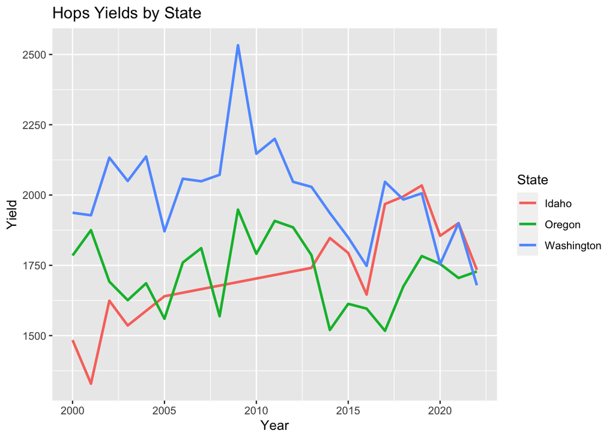

```r
yield <- add_row(hga_yield, missing_from_hga)

# we have two sets of dependent variables: yield by state and
# yield by variety and state
state_yields <- filter(yield, isTotal, !grepl("Pacific|United", Variety)) %>%
  select(-starts_with("is"), -Variety)

state_yields %>%
  ggplot(aes(x=Year, y=Yield, color=State)) +
  geom_line(linewidth = 1) +
  labs(title="Hops Yields by State")
```

```r
var_yields <- filter(yield, !isTotal) %>%
  select(-starts_with("is"))
head(var_yields, n=20)
```

| Variety | Yield | Year | State | File |
| --- | --- | --- | --- | --- |
| Cascade | 1802 | 2012 | Oregon | 10.pdf |
| Centennial | 1779 | 2012 | Oregon | 10.pdf |
| Golding | 1527 | 2012 | Oregon | 10.pdf |
| Liberty | 2519 | 2012 | Oregon | 10.pdf |
| Magnum | 1737 | 2012 | Oregon | 10.pdf |
| Millennium | NA | 2012 | Oregon | 10.pdf |
| Mt. Hood | 1737 | 2012 | Oregon | 10.pdf |
| Nugget | 2071 | 2012 | Oregon | 10.pdf |
| Perle | NA | 2012 | Oregon | 10.pdf |
| Sterling | NA | 2012 | Oregon | 10.pdf |

[output cut: 10 more lines]

```r
fwrite(state_yields, file = "hops_state_yields.csv")
fwrite(var_yields, file = "hops_variety_yields.csv")
```

### Hop growing counties in PNW

We expect environmental impacts to hop yields to be measurable locally, regardless of their source. For example wildfire smoke might negatively impact the quality and quantity of a harvest, whether the smoke originated nearby or hundreds of miles away.

While we prefer to incorporate climate and atmospheric observations near hop fields, yields are reported only at state level not county. Climate measures, pollutant concentrations, and air-quality factors that can impact hop harvests and yields are found in well-defined locations. For this analysis, we will use state declarations about hop growing counties to make more granular selection of meteorological and air quality samplers to prepare local observations.

Here, we manually assign a list of hop growing counties and join their FIPS codes for reference. Later we will join each county with its geographic boundaries to help select air quality sampler locations.

```r
hops_counties <- read.table(
  text = "county,state
Polk,OR
Marion,OR
Yakima,WA
Benton,WA
Canyon,ID
Boundary,ID
Owyhee,ID
Twin Falls,ID"
  ,header = TRUE, sep = ",", stringsAsFactors = FALSE
) %>%
  left_join(mutate(fips_codes, county = sub(" County", "", county)), by = c("state", "county")) %>%
  rename(State=state, County=county) %>%
  mutate(FIPS = paste0(state_code, county_code))

# IDAHO for year of 2023. Canyon contains the most growers.
# https://agri.idaho.gov/main/hop-growers-in-idaho/

# OREGON
# only Marion and Polk counties in Oregon grow commercially
# https://www.oregonencyclopedia.org/articles/hop_industry/

# other OR candidates in Willamette Valley include:
# Douglas,OR
# Lane,OR
# Linn,OR
# Benton,OR
# Yamhill,OR
# Washington,OR

fwrite(hops_counties, "hops_counties.csv")
```

### Climatic observations and preliminary analysis

```r
require(readr)
require(dplyr)
require(lubridate) # year()
require(archive)
require(keyring)
require(tigris) # counties()
require(sf) # st_transform

require(rnoaa) # ncdc_stations, use keyring::key_get("NCDC")

# source("outlier_test.R")

MAX_STATIONS = 25 # largest number of stations to sample with ncdc_stations()
```

```r
# we have a list of hops_counties
# get their wkt
# from tigris package, get all_counties=counties()
# counties_geo <- counties() %>%
#   st_transform(4326)

fn_gsoy_rds <- "~/Dropbox/Projects/Hops/GSOY.Rdata"

if (file.exists(fn_gsoy_rds)) {
  gsoy <- readRDS(fn_gsoy_rds)
} else {

  counties_geo <- counties(progress_bar = FALSE,
                           refresh = FALSE,
                           keep_zipped_shapefile = TRUE) %>%
    st_transform(4326)

  hops_geo <- left_join(hops_counties, counties_geo,
                        by = c("FIPS"="GEOID")) %>%
    group_by(FIPS) %>%
    group_split

  token = keyring::key_get("NCDC")

  hops_stations <- lapply(hops_geo, function(x) {
    ncdc_stations(datasetid="GSOY",
                  locationid = paste0("FIPS:", x["FIPS"]),
                  startdate = as.character(begin_date),
                  enddate = as.character(end_date),
                  limit = MAX_STATIONS,
                  sortfield = "datacoverage", # opting for max coverage
                  sortorder = "desc",
                  token = token)
  })

  cbind(select(hops_counties, county, state_name, FIPS),
        N_stations = unlist(lapply(hops_stations, function(x) nrow(x$data)))
  )

  # check coverage within each county. how many stations did we pull by county?

  # can we deal with potential 503 errors by saving the list and
  # reading the most recently saved list if service is unavailable?

  # extract each station list from the GSOY archive

  fn_stations <-
    lapply(hops_stations, function(x) {
      x$data
    }) %>%
    bind_rows %>%
    pull(id) %>%
    sub("GHCND:", "", .) %>%
    paste0(., ".csv") %>%
    unique
  cat(sprintf("Using %d unique GHCND stations\n", nrow(fn_stations)))

  # National Centers for Environmental Information (NCEI) URL for GSOY climate data
  url_gsoy <- "https://www.ncei.noaa.gov/data/global-summary-of-the-year/archive/gsoy-latest.tar.gz"

  # local GSOY archive, previously downloaded from NCEI
  # fn_gsoy <- "~/Dropbox/Data/NCEI/gsoy-latest.tar.gz"
  fn_gsoy <- paste0(path.data, "/NCEI/gsoy-latest.tar.gz")
  # download a fresh copy only if the file is missing or out-of-date
  # local.yr <- year(file.mtime(fn_gsoy))

  gsoy <- lapply(fn_stations, function(fn) {
    read_csv(archive_read(fn_gsoy, file = fn), col_types = cols()) %>%
      mutate(across(ends_with("_ATTRIBUTES"), function(a) as.character(a)))
  }) %>%
    bind_rows
  saveRDS(gsoy, file = fn_gsoy_rds)
}

ncdc_state_summaries <- gsoy %>%
  rename(Year = DATE) %>%
  filter(Year >= year(begin_date), Year <= year(end_date)) %>%
  select(-LATITUDE, -LONGITUDE, -ELEVATION) %>%
  mutate(state = substr(NAME, nchar(NAME)-4, nchar(NAME)-3)) %>%
  group_by(state, Year) %>%
  summarise(across(where(is.numeric), function(x) median(x, na.rm = TRUE)), .groups = "keep") %>%
  ungroup %>%
  mutate(State = case_when(state == "ID" ~ "Idaho"
                           ,state == "OR" ~ "Oregon"
                           ,state == "WA" ~ "Washington")) %>%
  select(State, Year, where(is.numeric))

# See GSOY readme for definition of observations
# https://www.ncei.noaa.gov/pub/data/metadata/documents/GSOYReadme.txt

ncdc_state_summaries
```

| State | Year | DP01 | DP10 | DP1X | EMXP | PRCP | CDSD | CLDD | DSND | DT00 | DT32 | DX32 | DX70 | DX90 | EMNT | EMSD | EMXT | FZF0 | FZF1 | FZF2 | FZF3 | FZF4 | FZF5 | FZF6 | FZF7 | FZF8 | FZF9 | HDSD | HTDD | … |
| --- | --- | --- | --- | --- | --- | --- | --- | --- | --- | --- | --- | --- | --- | --- | --- | --- | --- | --- | --- | --- | --- | --- | --- | --- | --- | --- | --- | --- | --- | --- |
| Idaho | 2000 | 88.0 | 46.0 | 0.0 | 17.00 | 340.40 | 139.30 | 139.30 | 92.5 | 0.0 | 159.0 | 36.0 | 109.0 | 22.0 | -16.70 | 355.5 | 36.70 | -2.20 | -3.30 | -6.70 | -7.20 | -9.40 | -0.60 | -3.30 | -4.40 | -11.10 | -11.10 | 3537.40 | 3537.40 | … |
| Idaho | 2001 | 92.0 | 40.0 | 0.0 | 20.60 | 346.50 | 479.80 | 479.80 | 92.5 | 0.0 | 135.0 | 27.0 | 143.0 | 43.5 | -14.40 | 266.5 | 38.90 | -1.70 | -2.80 | -5.00 | -7.80 | -9.40 | -0.60 | -2.80 | -4.40 | -8.90 | -9.80 | 3242.40 | 3242.40 | … |
| Idaho | 2002 | 55.0 | 20.0 | 0.0 | 20.60 | 134.20 | 292.80 | 292.80 | 28.0 | 0.0 | 149.5 | 16.0 | 134.5 | 32.0 | -13.60 | 254.0 | 40.55 | -3.90 | -3.90 | -5.00 | -8.30 | -11.10 | -2.25 | -2.50 | -6.50 | -8.05 | -10.25 | 2933.20 | 2933.20 | … |
| Idaho | 2003 | 91.5 | 46.5 | 0.5 | 26.80 | 375.15 | 246.60 | 246.60 | 0.0 | 0.0 | 148.0 | 17.5 | 145.5 | 53.5 | -14.40 | 0.0 | 40.25 | 0.00 | -6.30 | -6.30 | -9.40 | -11.65 | -1.10 | -4.40 | -4.80 | -6.70 | -9.40 | 3669.90 | 3669.90 | … |
| Idaho | 2004 | 115.0 | 53.0 | 0.0 | 24.10 | 280.30 | 162.70 | 162.70 | 78.5 | 3.0 | 116.0 | 20.5 | 116.5 | 27.5 | -22.70 | 419.5 | 36.65 | -0.50 | -2.70 | -5.60 | -6.90 | -9.45 | -0.10 | -2.60 | -6.80 | -8.20 | -8.90 | 3795.85 | 3795.85 | … |
| Idaho | 2005 | 110.0 | 83.5 | 3.0 | 29.85 | 512.30 | 116.00 | 116.00 | 62.5 | 5.0 | 127.5 | 39.0 | 105.0 | 14.0 | -24.45 | 343.0 | 35.60 | -1.00 | -2.60 | -5.25 | -7.15 | -10.40 | 0.00 | -2.30 | -4.70 | -7.15 | -9.20 | 3541.40 | 3541.40 | … |
| Idaho | 2006 | 125.0 | 125.0 | 5.0 | 43.20 | 690.50 | 209.75 | 209.75 | 75.0 | 2.0 | 139.5 | 26.0 | 105.0 | 13.0 | -20.35 | 317.5 | 35.90 | 0.00 | -3.05 | -7.25 | -9.05 | -9.15 | -1.95 | -2.50 | -5.00 | -8.70 | -10.30 | 4121.60 | 4121.60 | … |
| Idaho | 2007 | 89.5 | 68.0 | 2.0 | 39.35 | 311.75 | 215.00 | 215.00 | 8.0 | 2.0 | 129.5 | 31.0 | 111.0 | 26.0 | -18.45 | 25.0 | 38.30 | -0.30 | -3.20 | -4.95 | -7.35 | -9.35 | -0.50 | -3.15 | -5.35 | -8.40 | -9.95 | 3790.05 | 3790.05 | … |
| Idaho | 2008 | 96.0 | 75.5 | 0.0 | 23.65 | 456.20 | 122.40 | 122.40 | 140.0 | 7.5 | 165.0 | 31.0 | 107.0 | 14.0 | -22.60 | 940.0 | 37.80 | -0.50 | -3.05 | -5.00 | -7.10 | -10.20 | -1.10 | -3.05 | -5.80 | -7.15 | -9.40 | 4055.50 | 4055.50 | … |
| Idaho | 2009 | 80.0 | 31.0 | 1.0 | 25.40 | 232.40 | 152.20 | 152.20 | 185.5 | 4.0 | 152.5 | 38.5 | 103.5 | 8.5 | -20.25 | 1562.0 | 33.55 | -1.80 | -2.65 | -4.80 | -7.80 | -10.10 | -0.55 | -2.75 | -5.10 | -7.45 | -9.65 | 4111.25 | 4111.25 | … |

[output cut: 59 more lines]

```r
fwrite(ncdc_state_summaries, file = "climate_state_summaries.csv")
```

### Air quality observations and preliminary analysis

```r
require(dplyr)
require(rvest)
require(fwrite)
```

Air quality data are published by EPA. Because the hops yields are published annually, there is not much advantage to using the API. Instead we make a local repository from the EPA’s pre-made, annual AQI data sets.

```r
# get pre-made AQS data from Air Quality Index Report
url <- "https://aqs.epa.gov/aqsweb/airdata/download_files.html"
# local dir for AQS data archives
zipdir <- paste0(path.data, "/AQS/")
if (!dir.exists(zipdir)) dir.create(zipdir)
tmpdir <- Sys.getenv("TMPDIR")
```

We first download any air quality histories missing from our local archive. AQS data can be obtained for each reporting year by county. Once the local archive has been populated, it will only require (automated) updates each year unless we add more hops counties.

```r
# get list of zip archives on hand
zip_on_hand <- dir(zipdir, pattern = "*.zip") %>%
  tibble() %>%
  mutate(Local = TRUE) %>%
  rename(File = 1)

# get most recent set of archives available from NCUA
# and isolate zip hrefs
pg <- read_html(url)

zip_links <- pg %>%
  html_elements("a") %>%
  html_attr("href") %>%
  grep("annual_aqi_by_county_.*.[zZ][iI][pP]", ., value = TRUE) %>%
  paste(dirname(url), ., sep = "/")

# compare to previously obtained files
# n.b. `years` is defined in the HGA processing
zip_inventory <- bind_cols(URL = zip_links, File = basename(zip_links)) %>%
  # identify year from file name
  mutate(Year = as.numeric(gsub(".*_([0-9]{4}).zip", "\\1", File))) %>%
  arrange(Year) %>%
  left_join(zip_on_hand, by = "File") %>%
  mutate(Download = is.na(Local) & Year >= min(years))

# list gaps and download the files to archive location
zip_down <- filter(zip_inventory, Download) %>%
  data.frame
zip_down # missing from local set
```

| URL | File | Year | Local | Download |
| --- | --- | --- | --- | --- |

```r
# download missing files that met our date criteria
# n.b. this will overwrite existing files
if (nrow(zip_down) >0) {
  for (i in 1:nrow(zip_down)) {
    furl <- zip_down[i, "URL"]
    fio <- paste0(zipdir, zip_down[i, "File"])
    download.file(furl, destfile = fio, mode = "wb")
  }
}
```

Next, extract each zipped csv file and compile into a table and use a join to eliminate counties outside our hops growing regions.

```r
# combine local collection of files into a table, filter counties of interest
zips <- dir(zipdir, pattern = ".[zZ][iI[pP]", full.names = TRUE)

aqi_by_county <- lapply(zips, function(x) {
  zipc <- unzip(x, list = TRUE)
  exfiles <- grep("csv$", zipc$Name, value = TRUE, ignore.case = TRUE)
  tmp <- unzip(x, files = exfiles, exdir = tmpdir) %>%
    read.csv(., header = TRUE)
}) %>%
  bind_rows %>%
  right_join(hops_counties, by = c("State"="state_name", "County"))
aqi_by_county
```

| State | County | Year | Days.with.AQI | Good.Days | Moderate.Days | Unhealthy.for.Sensitive.Groups.Days | Unhealthy.Days | Very.Unhealthy.Days | Hazardous.Days | Max.AQI | X90th.Percentile.AQI | Median.AQI | Days.CO | Days.NO2 | Days.Ozone | Days.PM2.5 | Days.PM10 | State.y | state_code | county_code | FIPS |
| --- | --- | --- | --- | --- | --- | --- | --- | --- | --- | --- | --- | --- | --- | --- | --- | --- | --- | --- | --- | --- | --- |
| Idaho | Boundary | 2000 | 49 | 49 | 0 | 0 | 0 | 0 | 0 | 44 | 37 | 18 | 0 | 0 | 0 | 0 | 49 | ID | 16 | 021 | 16021 |
| Idaho | Canyon | 2000 | 366 | 313 | 49 | 4 | 0 | 0 | 0 | 117 | 55 | 32 | 227 | 0 | 0 | 50 | 89 | ID | 16 | 027 | 16027 |
| Idaho | Twin Falls | 2000 | 76 | 65 | 11 | 0 | 0 | 0 | 0 | 78 | 56 | 26 | 0 | 0 | 0 | 43 | 33 | ID | 16 | 083 | 16083 |
| Oregon | Marion | 2000 | 345 | 299 | 46 | 0 | 0 | 0 | 0 | 95 | 55 | 31 | 127 | 0 | 145 | 73 | 0 | OR | 41 | 047 | 41047 |
| Washington | Benton | 2000 | 336 | 291 | 41 | 4 | 0 | 0 | 0 | 138 | 58 | 19 | 0 | 0 | 0 | 76 | 260 | WA | 53 | 005 | 53005 |
| Washington | Yakima | 2000 | 366 | 345 | 18 | 3 | 0 | 0 | 0 | 124 | 35 | 15 | 261 | 0 | 0 | 53 | 52 | WA | 53 | 077 | 53077 |
| Idaho | Canyon | 2001 | 365 | 307 | 51 | 5 | 2 | 0 | 0 | 162 | 58 | 33 | 182 | 0 | 0 | 59 | 124 | ID | 16 | 027 | 16027 |
| Idaho | Twin Falls | 2001 | 129 | 116 | 13 | 0 | 0 | 0 | 0 | 83 | 51 | 26 | 0 | 0 | 0 | 96 | 33 | ID | 16 | 083 | 16083 |
| Oregon | Marion | 2001 | 335 | 307 | 27 | 1 | 0 | 0 | 0 | 134 | 47 | 29 | 114 | 0 | 143 | 78 | 0 | OR | 41 | 047 | 41047 |
| Washington | Benton | 2001 | 344 | 312 | 28 | 1 | 3 | 0 | 0 | 197 | 49 | 23 | 0 | 0 | 0 | 196 | 148 | WA | 53 | 005 | 53005 |

[output cut: 116 more lines]

```r
aqi_state_summaries <- aqi_by_county %>%
  filter(!is.na(Year)) %>%
  group_by(State, Year) %>%
  summarise(across(where(is.numeric), function(x) median(x, na.rm = TRUE)), .groups = "keep") %>%
  ungroup
aqi_state_summaries
```

| State | Year | Days.with.AQI | Good.Days | Moderate.Days | Unhealthy.for.Sensitive.Groups.Days | Unhealthy.Days | Very.Unhealthy.Days | Hazardous.Days | Max.AQI | X90th.Percentile.AQI | Median.AQI | Days.CO | Days.NO2 | Days.Ozone | Days.PM2.5 | Days.PM10 |
| --- | --- | --- | --- | --- | --- | --- | --- | --- | --- | --- | --- | --- | --- | --- | --- | --- |
| Idaho | 2000 | 76.0 | 65.0 | 11.0 | 0.0 | 0.0 | 0.0 | 0.0 | 78.0 | 55.0 | 26.0 | 0.0 | 0 | 0.0 | 43.0 | 49.0 |
| Idaho | 2001 | 247.0 | 211.5 | 32.0 | 2.5 | 1.0 | 0.0 | 0.0 | 122.5 | 54.5 | 29.5 | 91.0 | 0 | 0.0 | 77.5 | 78.5 |
| Idaho | 2002 | 125.0 | 111.0 | 14.0 | 1.0 | 0.0 | 0.0 | 0.0 | 102.0 | 55.0 | 25.0 | 1.0 | 0 | 0.0 | 56.0 | 20.0 |
| Idaho | 2003 | 365.0 | 275.0 | 14.0 | 0.0 | 0.0 | 0.0 | 0.0 | 97.0 | 46.0 | 23.0 | 23.0 | 0 | 0.0 | 44.0 | 50.0 |
| Idaho | 2004 | 266.0 | 243.0 | 23.0 | 0.0 | 0.0 | 0.0 | 0.0 | 88.0 | 49.0 | 27.0 | 0.0 | 0 | 0.0 | 107.0 | 0.0 |
| Idaho | 2005 | 326.0 | 267.0 | 32.0 | 2.0 | 0.0 | 0.0 | 0.0 | 114.0 | 52.0 | 27.0 | 0.0 | 0 | 0.0 | 156.0 | 0.0 |
| Idaho | 2006 | 332.5 | 255.5 | 75.0 | 2.0 | 0.0 | 0.0 | 0.0 | 97.0 | 60.0 | 34.5 | 1.0 | 0 | 46.5 | 259.5 | 25.5 |
| Idaho | 2007 | 328.5 | 247.5 | 80.0 | 1.0 | 0.0 | 0.0 | 0.0 | 110.0 | 60.5 | 33.5 | 0.0 | 0 | 0.0 | 299.5 | 29.0 |
| Idaho | 2008 | 311.0 | 274.0 | 37.0 | 0.0 | 0.0 | 0.0 | 0.0 | 89.0 | 52.5 | 27.5 | 0.0 | 0 | 0.0 | 255.0 | 56.0 |
| Idaho | 2009 | 323.5 | 299.0 | 24.0 | 0.5 | 0.0 | 0.0 | 0.0 | 98.0 | 46.5 | 23.0 | 0.0 | 0 | 0.0 | 203.5 | 120.0 |

[output cut: 62 more lines]

```r
fwrite(aqi_state_summaries, file = "aqi_state_summaries.csv")
```

Note that Polk County, OR and Owyhee County, ID do not have met stations that report as part of the AQS network.

The `Days.*` fields look promising for correlating yields to atmospheric chemistry measurements, while `*.Days` to the overall number of days at or exceeding human health AQI limits – similar to climatic summaries.